# WeRateDogs: Analysis and Visualization

## Introduction

The investigated dataset for this project is the tweet archive of Twitter user @dog_rates, also known as WeRateDogs. WeRateDogs is a Twitter account that rates people's dogs with a humorous comment about the dog. These ratings almost always have a denominator of 10. The numerators, though? Almost always greater than 10. 11/10, 12/10, 13/10, etc. Why? Because "they're good dogs Brent." WeRateDogs has over 4 million followers and has received international media coverage.

The dataset used for this project is made available by WeRateDogs. They downloaded their Twitter archive that contains basic tweet data (tweet ID, timestamp, text, etc.) for all 5000+ of their tweets as they stood on August 1, 2017.

Although the user ratings are not really serious, there are still plenty of research questions that are interesting to have answered. In this analysis, I focused on three questions:

1. Is there a difference in ratings between male and female dogs?
2. Which dog breed receives the highest ratings?
3. Did the average ratings change over time?

### 1. Is there a difference in ratings between male and female dogs?

```python
# Import statements
import pandas as pd
import numpy as np
import matplotlib.pyplot as plt
import matplotlib.dates as mdates
import seaborn as sns
import scipy.stats as stats
from wordcloud import WordCloud, STOPWORDS
%matplotlib inline
```

```python
# Load csv with WeRateDogs Twitter archive
tweets = pd.read_csv('twitter_archive_master.csv')
dogs = pd.read_csv('twitter_dog_info.csv')
```

```python
# Find the mean rating_numerator by gender
dogs.groupby(['gender']).mean()
```

| gender | tweet_id | rating_numerator | rating_denominator |
| --- | --- | --- | --- |
| female | 7.505240e+17 | 11.092391 | 10.0 |
| male | 7.382728e+17 | 12.559690 | 10.0 |
| unknown | 7.247451e+17 | 12.013487 | 10.0 |

When comparing the mean for each gender group, we see that the rating for female dogs is lower than for male dogs. In the plot below however, we can see that there are much less tweets that refer to a female dog than to a male dog.

```
male       1290
unknown     519
female      184
Name: gender, dtype: int64
```

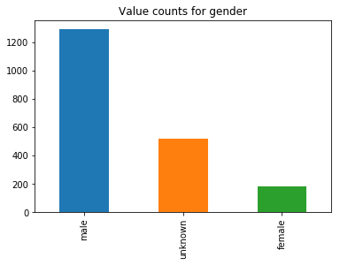

```python
# Inspect distribution of genders over the tweets
pd.value_counts(dogs['gender']).plot.bar()
plt.title("Value counts for gender")
print(dogs['gender'].value_counts())
```

```python
# Run independent samples t-test
males = dogs[dogs['gender'] == 'male']
females = dogs[dogs['gender'] == 'female']
stats.ttest_ind(males['rating_numerator'], females['rating_numerator'], equal_var=False)
```

```
Ttest_indResult(statistic=1.025957524736599, pvalue=0.3050986383979168)
```

Although the ratings usually are not very serious, we can still check if this difference in means is significant. Running a t-test shows that the mean rating numerator for male dogs is not significantly different from the mean rating numerator for female dogs, meaning that there is probably no real difference in the average rating numerator between male and female dogs.

### 2. Which dog breed receives the highest ratings?

When we run the mean average rating numerator per dog breed, we can see that both clumbers and soft coated wheaten terriers receive very high mean ratings (27 and 25 respectively). However, we also see that these ratings come from only a very small number of tweets, which makes the ratings not very reliable. To make this analysis a bit more meaningful, only dog breeds that received more than 25 ratings are included.

```
Text(0.5,1,'Mean rating numerator per dog breed')
```

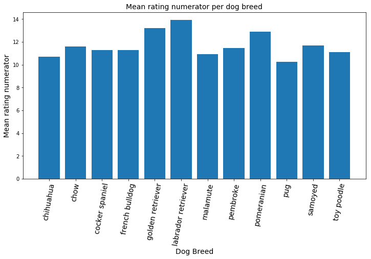

```python
# Create bar chart for skills that show the highest correlation with overall rating
breed = ['chihuahua', 'chow', 'cocker spaniel', 'french bulldog', 'golden retriever','labrador retriever', 'malamute',
         'pembroke','pomeranian', 'pug',  'samoyed', 'toy poodle']
mean_rating =  [10.71, 11.61, 11.30, 11.27, 13.21, 13.91, 10.90, 11.44, 12.87, 10.24, 11.70, 11.11]
y_pos = np.arange(len(breed))

fig, ax = plt.subplots(figsize=(12,6))
plt.bar(y_pos, mean_rating)
plt.xticks(y_pos, breed, rotation=80, fontsize=14)
plt.xlabel('Dog Breed', fontsize=14)
plt.ylabel('Mean rating numerator', fontsize=14)
plt.title('Mean rating numerator per dog breed', fontsize=14)
```

The two highest rated dog breeds that occurred 25 times or more in the tweets, Labrador Retriever and Golden Retriever, are both in the top 3 of most popular dog breeds according to the American Kennel Club. The lowest mean rating was for pugs, a breed that indeed may not meet the conventional dog beauty standards.

### 3. Did the average ratings change over time?

```python
# Load csv timestamp_analysis
timestamp_analysis = pd.read_csv('timestamp_analysis.csv')
timestamp_analysis['timestamp'] = pd.to_datetime(timestamp_analysis['timestamp'])
```

```python
# Calculate mean rating per week, sample code found at
# https://stackoverflow.com/questions/37842260/pandas-dataframe-resample-per-day-without-date-time-index?rq=1
ts_mean_by_week = timestamp_analysis.reset_index().set_index('timestamp').resample('W').mean()
```

```
Text(0.5,1,'Average WeRateDogs ratings per week')
```

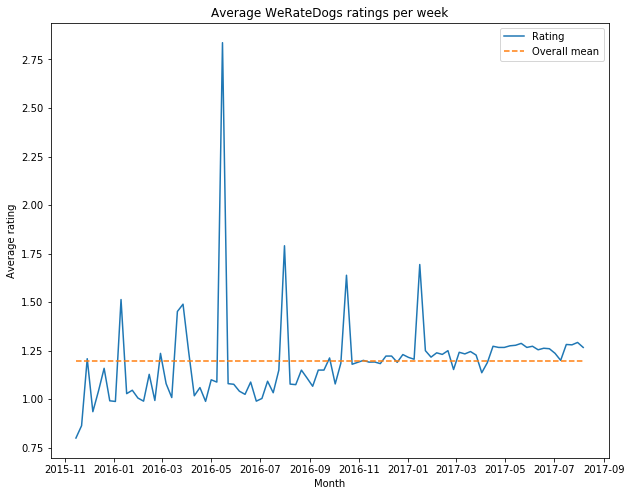

```python
x = ts_mean_by_week.index
y = ts_mean_by_week['rating_numerator']/10
y_overall_mean = [np.mean(y)]*len(x)

fig, ax = plt.subplots(figsize=(10,8))
# Plot the averages per month
ax.plot(x,y, label = 'Rating')
# Plot the average line
ax.plot(x,y_overall_mean, label='Overall mean', linestyle='--')
plt.legend = ax.legend(loc='upper right')
plt.xlabel('Month')
plt.ylabel('Average rating')
plt.title('Average WeRateDogs ratings per week')
```

There are some spikes in the trendline when ratings were given for multiple dogs. Again: the ratings are not very serious so this is no "hard" analysis but when we compare the trend line to the overall mean, there is an upward trend visible: the mean rating did increase over time. This might be due for the precise reason that the ratings are more playful than serious: as Twitter users see that more people are giving higher ratings, they follow this trend.

### Extra: the most frequently used words in the tweet texts

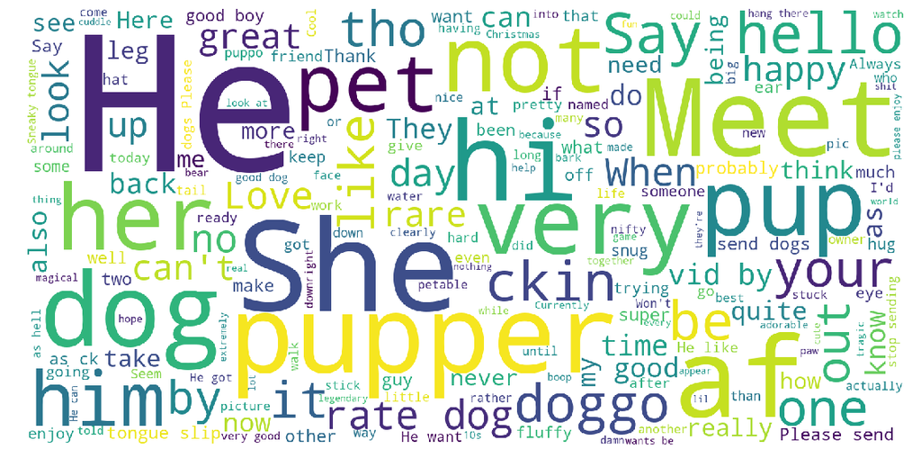

```python
ignore_words = {'https', 'co', 'https', 'and', 'the', 'would', 'of', 'for', 'is', 'this', 'that', 'these', 'with', 'to',
               'but', 'both', 'them', 'about', 'an', 'a', 'still', 'amp', 'it', 'on', 'in', 'all', 'you', 'here',
                'have', 'get', 'from', 'are', 'was', 'will', 'only', 'we', 'has', 'just', 'too', "I'm", "doesn't",
               "don't", "you're", "won't" 'your'}
wordcloud = WordCloud(background_color="white", stopwords = ignore_words, width=1600, height=800).generate(' '.join(tweets['text']))

# Generate plot
plt.figure(figsize=(20,10))
plt.imshow(wordcloud)
plt.axis("off")
plt.show()
```

To conclude, I generated a word cloud of the words most frequently used in the tweet texts. Please note that the stopwords are left out quite arbitrarily. Again: this is not an in-depth analysis but a nice way to get a feeling for the vocabulary of the WeRateDogs tweets.

The most common words refer to the dog's gender, like "She", "he, "her" and "him". Looking at the font size of the words, tweets about pups/puppers are more common than about older dogs (which would make sense as puppies are very photogenic). Also, the common way to introduce dogs is clearly visible in the word cloud: "Meet [dog name]" and "Say hi/hello to [dog name]" are used often. The dog owners apparently also talk about body parts of their dogs, in the word cloud "leg", "tail", "paw" and "ear" can be found.

And finally, we see words like "af", an internet slang acronym used often on social media. It stands for "as f#ck". The same is true for "ckin" which is used in the tweets as "h#ckin". This word comes, according to [Esquire](https://www.esquire.com/lifestyle/a54940/we-rate-dogs-matt-nelson-interview/) from ""oh h#ck," a silly censoring of an already-family-friendly word that strikes so many people as so funny that Nelson now sells hundreds of hats, mugs, and shirts with the phrase every month." H#cking, doggo, pupper, boop... all words from the DoggoLingo internet language to which WeRateDogs made a great contribution.